# Final Project

Group 16

12/17/2021

## Data Preparation and EDA

```r
library(dplyr)
library(MASS)
library(ggplot2)
library(GGally)
library(leaps)
library(tidyverse)
library(performance)
library(patchwork)
library(interactions)
library(modelr)
library(caret)
crime_df =
  read_csv("cdi.csv") %>%
  mutate(
    region = factor(region),
    pop_density = pop / area,
    beds_density_1000 =1000 * beds / pop,
    docs_density_1000 =1000 * docs / pop,
    crm_1000 = 1000 * crimes / pop
  ) %>%
  dplyr::select(-crimes, -id,-area, -pop, -beds, -docs) %>%
  dplyr::select(crm_1000, everything()) %>%
  drop_na()
```

## Independent Variable Selection

First examine the marginal distributions of each variable.

```r
#Load data
crime_df1 =
  read_csv("cdi.csv") %>%
  mutate(
    region = factor(region),
    pop_density = pop / area,
    crm_1000 = 1000 * crimes / pop
  ) %>%
  dplyr::select(-pop, -id, -cty, -state, -area, -crimes)
```

To begin with, we take a look on the distribution of crime rate per 1000 population. We find that Kings County in NY is an extreme outlier with close to 300 crime rate, so we may not include this data in the following analysis.

First examine the marginal distributions of each variable.

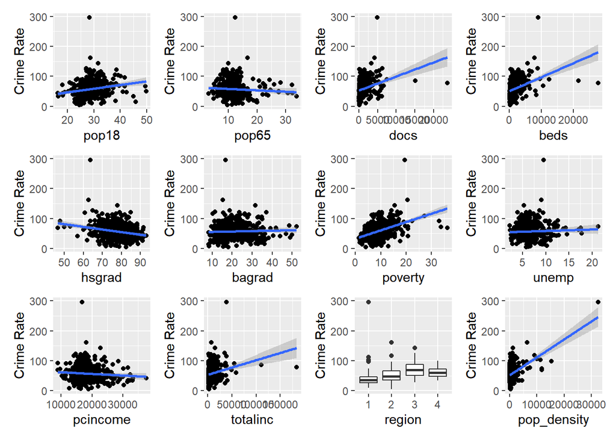

```r
# graph
compute_plist = function(x) {
  if (is.factor(x)) {
    pl = crime_df1 %>%
    ggplot(aes(x = x, y = crm_1000)) +
    geom_boxplot() +
    labs(
      x = '',
      y = "Crime Rate",
    )
  } else {
    pl = crime_df1 %>%
    ggplot(aes(x = x, y = crm_1000)) +
    geom_point() +
    geom_smooth(method = "lm") +
    labs(
      x = '',
      y = "Crime Rate",
    )
  }
  return(pl)
}

plist = crime_df1 %>%
  dplyr::select(-crm_1000) %>%
  map(compute_plist)

labels = crime_df1 %>%
  dplyr::select(-crm_1000) %>%
  names()

for (i in 1:length(plist)) {
  plist[[i]] = plist[[i]] + labs(x = labels[[i]])
}

wrap_plots(plist, ncol = 4)
```

Compare p-value of all variables

```r
compute_p_value = function(x) {
  lm_data = lm(crm_1000 ~ x, data = crime_df1)
  if (is.factor(x)) {
    return( lm_data %>% broom::tidy() %>% dplyr::select(p.value) %>% .[2:4,1])
  }
  return(lm_data %>% broom::tidy() %>% dplyr::select(p.value) %>% .[2,1])
}

labels_list <- c("pop18","pop65","docs","beds","hsgrad","bagrad","poverty","unemp","pcincome","totalinc","region_1","region_2", "region_3", "pop_density")

p_values = crime_df1 %>%
  dplyr::select(-crm_1000) %>%
  map_df(compute_p_value) %>%
  mutate(Variables = labels_list)

p_values
```

```
## # A tibble: 14 x 2
##     p.value Variables
##       <dbl> <chr>
##  1 5.75e- 5 pop18
##  2 1.64e- 1 pop65
##  3 4.31e-11 docs
##  4 1.44e-17 beds
##  5 1.60e- 6 hsgrad
##  6 4.23e- 1 bagrad
##  7 8.92e-26 poverty
##  8 3.81e- 1 unemp
##  9 9.27e- 2 pcincome
## 10 1.32e- 6 totalinc
## 11 4.06e- 3 region_1
## 12 6.09e-19 region_2
## 13 2.33e- 7 region_3
## 14 8.66e-27 pop_density
```

### Backward & Forward & Stepwise

```r
crime_df2 =
  read_csv("cdi.csv") %>%
  mutate(
    region = factor(region),
    pop_density = pop / area,
    crm_1000 = 1000 * crimes / pop,
    beds_density_1000 = 1000 * beds / pop,
    docs_density_1000 = 1000 * docs / pop
  ) %>%
  dplyr::select(-crimes, -id, -area, -pop, -cty, -state, -beds, -docs, -region) %>%
  dplyr::select(crm_1000, everything())
# fit regression using all predictors
mult.fit = lm(crm_1000 ~ ., data = crime_df)

step(mult.fit, direction = 'backward')
```

```
## Start:  AIC=1765.64
## crm_1000 ~ cty + state + pop18 + pop65 + hsgrad + bagrad + poverty +
##     unemp + pcincome + totalinc + region + pop_density + beds_density_1000 +
##     docs_density_1000
##
##
## Step:  AIC=1765.64
## crm_1000 ~ cty + state + pop18 + pop65 + hsgrad + bagrad + poverty +
##     unemp + pcincome + totalinc + pop_density + beds_density_1000 +
##     docs_density_1000
##
##                      Df Sum of Sq    RSS    AIC
## <none>                              3706 1765.6
## - pcincome            1        26   3732 1766.7
## - unemp               1        32   3738 1767.5
## - bagrad              1        35   3741 1767.7
## - docs_density_1000   1        76   3782 1772.6
## - pop65               1        77   3784 1772.7
## - pop18               1       387   4093 1807.3
## - poverty             1       498   4205 1819.2
## - totalinc            1       508   4215 1820.2
## - hsgrad              1       679   4385 1837.6
## - beds_density_1000   1      1290   4996 1895.0
## - pop_density         1      4517   8223 2114.3
## - state              32     15372  19079 2422.6
## - cty               355    101037 104744 2525.9
```

```
##
## Call:
## lm(formula = crm_1000 ~ cty + state + pop18 + pop65 + hsgrad +
##     bagrad + poverty + unemp + pcincome + totalinc + pop_density +
##     beds_density_1000 + docs_density_1000, data = crime_df)
##
## Coefficients:
##       (Intercept)           ctyAdams           ctyAiken         ctyAlachua
##        -1.413e+02          5.860e+01          1.670e+01          6.303e+01
##       ctyAlamance         ctyAlameda          ctyAlbany        ctyAlexandr
##         1.124e+01          7.292e+01          4.350e+01          4.808e+00
##       ctyAlleghen           ctyAllen        ctyAnderson        ctyAndrosco
##        -4.096e+00          1.648e+01          2.195e+01          3.582e+01
##       ctyAnne_Aru        ctyArapahoe        ctyArlingto        ctyAtlantic
##         4.070e+01          3.090e+01          1.139e+01          7.021e+01
##       ctyBaltimor        ctyBarnstab             ctyBay          ctyBeaver
##         5.193e+01          2.200e+00          1.590e+01          1.162e+01
##           ctyBell          ctyBenton          ctyBergen           ctyBerks
##         2.194e+01          4.730e+01         -3.609e+01          5.886e+01
##       ctyBerkshir        ctyBernalil         ctyBerrien           ctyBexar
##         8.004e+00          3.769e+01          3.711e+01          5.387e+01
##           ctyBibb           ctyBlair           ctyBoone         ctyBoulder
##         3.231e+01          5.719e+00          7.610e+00          4.492e+01
##       ctyBrazoria          ctyBrazos         ctyBrevard         ctyBristol
##         1.635e+01          6.896e+01          1.092e+01          4.708e+01
##         ctyBroome         ctyBroward           ctyBrown           ctyBucks
##         2.360e+01          1.446e+01          3.513e+01          2.237e+01
##       ctyBuncombe        ctyBurlingt          ctyButler           ctyButte
##         1.308e+00         -9.773e+00          3.100e+01          5.405e+01
##          ctyCaddo        ctyCalcasie         ctyCalhoun         ctyCambria
##        -2.371e+01         -4.654e+01          2.394e+01          6.812e+00
##         ctyCamden         ctyCameron         ctyCarroll            ctyCass
##         1.211e+01          2.637e+01          2.872e+01         -1.564e+01
##        ctyCatawba          ctyCentre        ctyChampaig         ctyCharles
##         2.605e+01          7.667e+01          4.753e+01          4.869e+01
##       ctyCharlest        ctyCharlott         ctyChatham        ctyChautauq
##         2.844e+01         -1.898e+01          3.759e+01          1.310e+01
##       ctyChesapea         ctyChester        ctyChittend        ctyClackama
##         3.327e+01          2.417e+01          1.080e+01          2.567e+01
##          ctyClark            ctyClay         ctyClayton        ctyClermont
```

[output cut: 168 more lines]

```
##                NA         -1.310e+01         -2.217e+01         -1.422e+01
##           stateOK            stateOR            statePA            stateRI
##                NA         -2.067e+01         -3.902e+01         -1.236e+01
##           stateSC            stateSD            stateTN            stateTX
##         2.253e+01                 NA          2.136e+01          4.582e+00
##           stateUT            stateVA            stateVT            stateWA
##                NA                 NA                 NA         -4.344e+01
##           stateWI            stateWV              pop18              pop65
##        -3.650e+01                 NA         -1.974e+00         -8.130e-01
##            hsgrad             bagrad            poverty              unemp
##         2.397e+00         -5.758e-01          2.404e+00          1.298e+00
##          pcincome           totalinc        pop_density  beds_density_1000
##         1.013e-03          7.426e-04          5.560e-03          6.992e+00
## docs_density_1000
##        -3.069e+00
```

```r
step(mult.fit, direction = 'forward')
```

```
## Start:  AIC=1765.64
## crm_1000 ~ cty + state + pop18 + pop65 + hsgrad + bagrad + poverty +
##     unemp + pcincome + totalinc + region + pop_density + beds_density_1000 +
##     docs_density_1000
```

```
##
## Call:
## lm(formula = crm_1000 ~ cty + state + pop18 + pop65 + hsgrad +
##     bagrad + poverty + unemp + pcincome + totalinc + region +
##     pop_density + beds_density_1000 + docs_density_1000, data = crime_df)
##
## Coefficients:
##       (Intercept)           ctyAdams           ctyAiken         ctyAlachua
##        -1.413e+02          5.860e+01          1.670e+01          6.303e+01
##       ctyAlamance         ctyAlameda          ctyAlbany        ctyAlexandr
##         1.124e+01          7.292e+01          4.350e+01          4.808e+00
##       ctyAlleghen           ctyAllen        ctyAnderson        ctyAndrosco
##        -4.096e+00          1.648e+01          2.195e+01          3.582e+01
##       ctyAnne_Aru        ctyArapahoe        ctyArlingto        ctyAtlantic
##         4.070e+01          3.090e+01          1.139e+01          7.021e+01
##       ctyBaltimor        ctyBarnstab             ctyBay          ctyBeaver
##         5.193e+01          2.200e+00          1.590e+01          1.162e+01
##           ctyBell          ctyBenton          ctyBergen           ctyBerks
##         2.194e+01          4.730e+01         -3.609e+01          5.886e+01
##       ctyBerkshir        ctyBernalil         ctyBerrien           ctyBexar
##         8.004e+00          3.769e+01          3.711e+01          5.387e+01
##           ctyBibb           ctyBlair           ctyBoone         ctyBoulder
##         3.231e+01          5.719e+00          7.610e+00          4.492e+01
##       ctyBrazoria          ctyBrazos         ctyBrevard         ctyBristol
##         1.635e+01          6.896e+01          1.092e+01          4.708e+01
##         ctyBroome         ctyBroward           ctyBrown           ctyBucks
##         2.360e+01          1.446e+01          3.513e+01          2.237e+01
##       ctyBuncombe        ctyBurlingt          ctyButler           ctyButte
##         1.308e+00         -9.773e+00          3.100e+01          5.405e+01
##          ctyCaddo        ctyCalcasie         ctyCalhoun         ctyCambria
##        -2.371e+01         -4.654e+01          2.394e+01          6.812e+00
##         ctyCamden         ctyCameron         ctyCarroll            ctyCass
##         1.211e+01          2.637e+01          2.872e+01         -1.564e+01
##        ctyCatawba          ctyCentre        ctyChampaig         ctyCharles
##         2.605e+01          7.667e+01          4.753e+01          4.869e+01
##       ctyCharlest        ctyCharlott         ctyChatham        ctyChautauq
##         2.844e+01         -1.898e+01          3.759e+01          1.310e+01
##       ctyChesapea         ctyChester        ctyChittend        ctyClackama
##         3.327e+01          2.417e+01          1.080e+01          2.567e+01
##          ctyClark            ctyClay         ctyClayton        ctyClermont
```

[output cut: 168 more lines]

```
##                NA         -1.310e+01         -2.217e+01         -1.422e+01
##           stateOK            stateOR            statePA            stateRI
##                NA         -2.067e+01         -3.902e+01         -1.236e+01
##           stateSC            stateSD            stateTN            stateTX
##         2.253e+01                 NA          2.136e+01          4.582e+00
##           stateUT            stateVA            stateVT            stateWA
##                NA                 NA                 NA         -4.344e+01
##           stateWI            stateWV              pop18              pop65
##        -3.650e+01                 NA         -1.974e+00         -8.130e-01
##            hsgrad             bagrad            poverty              unemp
##         2.397e+00         -5.758e-01          2.404e+00          1.298e+00
##          pcincome           totalinc            region2            region3
##         1.013e-03          7.426e-04                 NA                 NA
##           region4        pop_density  beds_density_1000  docs_density_1000
##                NA          5.560e-03          6.992e+00         -3.069e+00
```

```r
step(mult.fit, direction = 'both')
```

```
## Start:  AIC=1765.64
## crm_1000 ~ cty + state + pop18 + pop65 + hsgrad + bagrad + poverty +
##     unemp + pcincome + totalinc + region + pop_density + beds_density_1000 +
##     docs_density_1000
##
##
## Step:  AIC=1765.64
## crm_1000 ~ cty + state + pop18 + pop65 + hsgrad + bagrad + poverty +
##     unemp + pcincome + totalinc + pop_density + beds_density_1000 +
##     docs_density_1000
##
##                      Df Sum of Sq    RSS    AIC
## <none>                              3706 1765.6
## - pcincome            1        26   3732 1766.7
## - unemp               1        32   3738 1767.5
## - bagrad              1        35   3741 1767.7
## - docs_density_1000   1        76   3782 1772.6
## - pop65               1        77   3784 1772.7
## - pop18               1       387   4093 1807.3
## - poverty             1       498   4205 1819.2
## - totalinc            1       508   4215 1820.2
## - hsgrad              1       679   4385 1837.6
## - beds_density_1000   1      1290   4996 1895.0
## - pop_density         1      4517   8223 2114.3
## - state              32     15372  19079 2422.6
## - cty               355    101037 104744 2525.9
```

```
##
## Call:
## lm(formula = crm_1000 ~ cty + state + pop18 + pop65 + hsgrad +
##     bagrad + poverty + unemp + pcincome + totalinc + pop_density +
##     beds_density_1000 + docs_density_1000, data = crime_df)
##
## Coefficients:
##       (Intercept)           ctyAdams           ctyAiken         ctyAlachua
##        -1.413e+02          5.860e+01          1.670e+01          6.303e+01
##       ctyAlamance         ctyAlameda          ctyAlbany        ctyAlexandr
##         1.124e+01          7.292e+01          4.350e+01          4.808e+00
##       ctyAlleghen           ctyAllen        ctyAnderson        ctyAndrosco
##        -4.096e+00          1.648e+01          2.195e+01          3.582e+01
##       ctyAnne_Aru        ctyArapahoe        ctyArlingto        ctyAtlantic
##         4.070e+01          3.090e+01          1.139e+01          7.021e+01
##       ctyBaltimor        ctyBarnstab             ctyBay          ctyBeaver
##         5.193e+01          2.200e+00          1.590e+01          1.162e+01
##           ctyBell          ctyBenton          ctyBergen           ctyBerks
##         2.194e+01          4.730e+01         -3.609e+01          5.886e+01
##       ctyBerkshir        ctyBernalil         ctyBerrien           ctyBexar
##         8.004e+00          3.769e+01          3.711e+01          5.387e+01
##           ctyBibb           ctyBlair           ctyBoone         ctyBoulder
##         3.231e+01          5.719e+00          7.610e+00          4.492e+01
##       ctyBrazoria          ctyBrazos         ctyBrevard         ctyBristol
##         1.635e+01          6.896e+01          1.092e+01          4.708e+01
##         ctyBroome         ctyBroward           ctyBrown           ctyBucks
##         2.360e+01          1.446e+01          3.513e+01          2.237e+01
##       ctyBuncombe        ctyBurlingt          ctyButler           ctyButte
##         1.308e+00         -9.773e+00          3.100e+01          5.405e+01
##          ctyCaddo        ctyCalcasie         ctyCalhoun         ctyCambria
##        -2.371e+01         -4.654e+01          2.394e+01          6.812e+00
##         ctyCamden         ctyCameron         ctyCarroll            ctyCass
##         1.211e+01          2.637e+01          2.872e+01         -1.564e+01
##        ctyCatawba          ctyCentre        ctyChampaig         ctyCharles
##         2.605e+01          7.667e+01          4.753e+01          4.869e+01
##       ctyCharlest        ctyCharlott         ctyChatham        ctyChautauq
##         2.844e+01         -1.898e+01          3.759e+01          1.310e+01
##       ctyChesapea         ctyChester        ctyChittend        ctyClackama
##         3.327e+01          2.417e+01          1.080e+01          2.567e+01
##          ctyClark            ctyClay         ctyClayton        ctyClermont
```

[output cut: 168 more lines]

```
##                NA         -1.310e+01         -2.217e+01         -1.422e+01
##           stateOK            stateOR            statePA            stateRI
##                NA         -2.067e+01         -3.902e+01         -1.236e+01
##           stateSC            stateSD            stateTN            stateTX
##         2.253e+01                 NA          2.136e+01          4.582e+00
##           stateUT            stateVA            stateVT            stateWA
##                NA                 NA                 NA         -4.344e+01
##           stateWI            stateWV              pop18              pop65
##        -3.650e+01                 NA         -1.974e+00         -8.130e-01
##            hsgrad             bagrad            poverty              unemp
##         2.397e+00         -5.758e-01          2.404e+00          1.298e+00
##          pcincome           totalinc        pop_density  beds_density_1000
##         1.013e-03          7.426e-04          5.560e-03          6.992e+00
## docs_density_1000
##        -3.069e+00
```

## Test Based Procedures

```r
mat = as.matrix(crime_df2)
# Printing the 2 best models of each size, using the Cp criterion:
leaps(x = mat[,2:12], y = mat[,1], nbest = 2, method = "Cp")
```

```
## $which
##        1     2     3     4     5     6     7     8     9     A     B
## 1  FALSE FALSE FALSE FALSE FALSE FALSE FALSE FALSE  TRUE FALSE FALSE
## 1  FALSE FALSE FALSE FALSE  TRUE FALSE FALSE FALSE FALSE FALSE FALSE
## 2  FALSE FALSE FALSE FALSE  TRUE FALSE FALSE FALSE  TRUE FALSE FALSE
## 2  FALSE FALSE FALSE FALSE FALSE FALSE FALSE FALSE  TRUE  TRUE FALSE
## 3  FALSE FALSE FALSE FALSE  TRUE  TRUE FALSE FALSE  TRUE FALSE FALSE
## 3  FALSE FALSE FALSE  TRUE  TRUE FALSE FALSE FALSE  TRUE FALSE FALSE
## 4  FALSE FALSE FALSE FALSE  TRUE  TRUE FALSE  TRUE  TRUE FALSE FALSE
## 4  FALSE FALSE FALSE  TRUE  TRUE FALSE FALSE FALSE  TRUE  TRUE FALSE
## 5  FALSE FALSE FALSE FALSE  TRUE  TRUE FALSE  TRUE  TRUE  TRUE FALSE
## 5  FALSE FALSE  TRUE FALSE  TRUE FALSE FALSE  TRUE  TRUE  TRUE FALSE
## 6  FALSE FALSE  TRUE FALSE  TRUE  TRUE FALSE  TRUE  TRUE  TRUE FALSE
## 6   TRUE FALSE FALSE FALSE  TRUE  TRUE FALSE  TRUE  TRUE  TRUE FALSE
## 7   TRUE FALSE  TRUE FALSE  TRUE  TRUE FALSE  TRUE  TRUE  TRUE FALSE
```

[output cut: 22 more lines]

```r
# Printing the 2 best models of each size, using the adjusted R^2 criterion:
leaps(x = mat[,2:12], y = mat[,1], nbest = 2, method = "adjr2")
```

```
## $which
##        1     2     3     4     5     6     7     8     9     A     B
## 1  FALSE FALSE FALSE FALSE FALSE FALSE FALSE FALSE  TRUE FALSE FALSE
## 1  FALSE FALSE FALSE FALSE  TRUE FALSE FALSE FALSE FALSE FALSE FALSE
## 2  FALSE FALSE FALSE FALSE  TRUE FALSE FALSE FALSE  TRUE FALSE FALSE
## 2  FALSE FALSE FALSE FALSE FALSE FALSE FALSE FALSE  TRUE  TRUE FALSE
## 3  FALSE FALSE FALSE FALSE  TRUE  TRUE FALSE FALSE  TRUE FALSE FALSE
## 3  FALSE FALSE FALSE  TRUE  TRUE FALSE FALSE FALSE  TRUE FALSE FALSE
## 4  FALSE FALSE FALSE FALSE  TRUE  TRUE FALSE  TRUE  TRUE FALSE FALSE
## 4  FALSE FALSE FALSE  TRUE  TRUE FALSE FALSE FALSE  TRUE  TRUE FALSE
## 5  FALSE FALSE FALSE FALSE  TRUE  TRUE FALSE  TRUE  TRUE  TRUE FALSE
## 5  FALSE FALSE  TRUE FALSE  TRUE FALSE FALSE  TRUE  TRUE  TRUE FALSE
## 6  FALSE FALSE  TRUE FALSE  TRUE  TRUE FALSE  TRUE  TRUE  TRUE FALSE
## 6   TRUE FALSE FALSE FALSE  TRUE  TRUE FALSE  TRUE  TRUE  TRUE FALSE
## 7   TRUE FALSE  TRUE FALSE  TRUE  TRUE FALSE  TRUE  TRUE  TRUE FALSE
```

[output cut: 21 more lines]

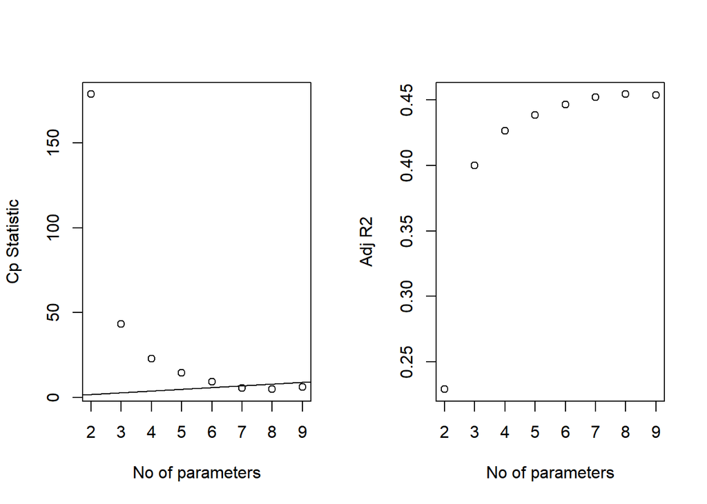

```r
# Function regsubsets() performs a subset selection by identifying the "best" model that contains
# a certain number of predictors. By default "best" is chosen using SSE/RSS (smaller is better)
b = regsubsets(crm_1000 ~ ., data = crime_df2)
rs = summary(b)

# plot of Cp and Adj-R2 as functions of parameters
par(mfrow=c(1,2))

plot(2:9, rs$cp, xlab="No of parameters", ylab="Cp Statistic")
abline(0,1)
#6
plot(2:9, rs$adjr2, xlab="No of parameters", ylab="Adj R2")
```

```r
#6
```

```r
Model_backward =
lm(formula = crm_1000 ~ pop18 + hsgrad + bagrad + poverty + pcincome + totalinc + region + pop_density + beds_density_1000, data = crime_df)
summary(Model_backward)
```

```
##
## Call:
## lm(formula = crm_1000 ~ pop18 + hsgrad + bagrad + poverty + pcincome +
##     totalinc + region + pop_density + beds_density_1000, data = crime_df)
##
## Residuals:
##    Min     1Q Median     3Q    Max
## -50.29 -11.31  -0.85  10.43  76.83
##
## Coefficients:
##                     Estimate Std. Error t value Pr(>|t|)
## (Intercept)       -6.658e+01  2.462e+01  -2.704 0.007114 **
## pop18              8.036e-01  2.861e-01   2.808 0.005208 **
## hsgrad             5.786e-01  2.641e-01   2.191 0.028998 *
## bagrad            -6.045e-01  2.831e-01  -2.135 0.033329 *
## poverty            2.061e+00  3.618e-01   5.696 2.28e-08 ***
## pcincome           1.102e-03  4.714e-04   2.338 0.019866 *
## totalinc           1.996e-04  7.622e-05   2.619 0.009136 **
## region2            9.145e+00  2.668e+00   3.428 0.000668 ***
## region3            2.710e+01  2.533e+00  10.699  < 2e-16 ***
## region4            2.127e+01  3.080e+00   6.906 1.81e-11 ***
## pop_density        4.941e-03  4.494e-04  10.995  < 2e-16 ***
## beds_density_1000  2.484e+00  5.042e-01   4.926 1.20e-06 ***
## ---
## Signif. codes:  0 '***' 0.001 '**' 0.01 '*' 0.05 '.' 0.1 ' ' 1
##
## Residual standard error: 17.88 on 428 degrees of freedom
## Multiple R-squared:  0.5827, Adjusted R-squared:  0.572
## F-statistic: 54.33 on 11 and 428 DF,  p-value: < 2.2e-16
```

```r
BIC(Model_backward)
```

```
## [1] 3853.23
```

```r
Model_forward =
  lm(formula = crm_1000 ~ pop18 + pop65 + hsgrad + bagrad + poverty + unemp + pcincome + totalinc + region + pop_density + beds_density_1000 + docs_density_1000, data = crime_df)
BIC(Model_forward)
```

```
## [1] 3869.53
```

```r
summary(Model_forward)
```

```
##
## Call:
## lm(formula = crm_1000 ~ pop18 + pop65 + hsgrad + bagrad + poverty +
##     unemp + pcincome + totalinc + region + pop_density + beds_density_1000 +
##     docs_density_1000, data = crime_df)
##
## Residuals:
##     Min      1Q  Median      3Q     Max
## -48.570 -11.549  -0.911  10.417  75.670
##
## Coefficients:
##                     Estimate Std. Error t value Pr(>|t|)
## (Intercept)       -6.862e+01  2.757e+01  -2.489  0.01319 *
## pop18              7.160e-01  3.327e-01   2.152  0.03198 *
## pop65             -1.993e-01  3.072e-01  -0.649  0.51695
## hsgrad             6.074e-01  2.706e-01   2.245  0.02529 *
## bagrad            -4.964e-01  2.988e-01  -1.662  0.09733 .
## poverty            1.879e+00  3.887e-01   4.836 1.86e-06 ***
## unemp              6.015e-01  5.345e-01   1.125  0.26109
## pcincome           1.029e-03  4.846e-04   2.123  0.03432 *
## totalinc           2.072e-04  7.652e-05   2.707  0.00705 **
## region2            9.098e+00  2.747e+00   3.312  0.00101 **
## region3            2.785e+01  2.673e+00  10.419  < 2e-16 ***
## region4            2.160e+01  3.140e+00   6.879 2.16e-11 ***
## pop_density        5.006e-03  4.536e-04  11.037  < 2e-16 ***
## beds_density_1000  3.138e+00  7.988e-01   3.928  0.00010 ***
## docs_density_1000 -6.554e-01  1.025e+00  -0.639  0.52298
## ---
## Signif. codes:  0 '***' 0.001 '**' 0.01 '*' 0.05 '.' 0.1 ' ' 1
##
## Residual standard error: 17.9 on 425 degrees of freedom
## Multiple R-squared:  0.5845, Adjusted R-squared:  0.5708
## F-statistic: 42.71 on 14 and 425 DF,  p-value: < 2.2e-16
```

```r
Model_stepwise =
  lm(formula = crm_1000 ~ pop18 + hsgrad + bagrad + poverty + pcincome + totalinc + region + pop_density + beds_density_1000, data = crime_df)
summary(Model_stepwise)
```

```
##
## Call:
## lm(formula = crm_1000 ~ pop18 + hsgrad + bagrad + poverty + pcincome +
##     totalinc + region + pop_density + beds_density_1000, data = crime_df)
##
## Residuals:
##    Min     1Q Median     3Q    Max
## -50.29 -11.31  -0.85  10.43  76.83
##
## Coefficients:
##                     Estimate Std. Error t value Pr(>|t|)
## (Intercept)       -6.658e+01  2.462e+01  -2.704 0.007114 **
## pop18              8.036e-01  2.861e-01   2.808 0.005208 **
## hsgrad             5.786e-01  2.641e-01   2.191 0.028998 *
## bagrad            -6.045e-01  2.831e-01  -2.135 0.033329 *
## poverty            2.061e+00  3.618e-01   5.696 2.28e-08 ***
## pcincome           1.102e-03  4.714e-04   2.338 0.019866 *
## totalinc           1.996e-04  7.622e-05   2.619 0.009136 **
## region2            9.145e+00  2.668e+00   3.428 0.000668 ***
## region3            2.710e+01  2.533e+00  10.699  < 2e-16 ***
## region4            2.127e+01  3.080e+00   6.906 1.81e-11 ***
## pop_density        4.941e-03  4.494e-04  10.995  < 2e-16 ***
## beds_density_1000  2.484e+00  5.042e-01   4.926 1.20e-06 ***
## ---
## Signif. codes:  0 '***' 0.001 '**' 0.01 '*' 0.05 '.' 0.1 ' ' 1
##
## Residual standard error: 17.88 on 428 degrees of freedom
## Multiple R-squared:  0.5827, Adjusted R-squared:  0.572
## F-statistic: 54.33 on 11 and 428 DF,  p-value: < 2.2e-16
```

```r
BIC(Model_stepwise)
```

```
## [1] 3853.23
```

```r
cp1 =
  lm(formula = crm_1000 ~ pop18 + hsgrad + poverty + unemp + totalinc + pop_density + docs_density_1000, data = crime_df2)
BIC(cp1)
```

```
## [1] 3943.759
```

```r
summary(cp1)
```

```
##
## Call:
## lm(formula = crm_1000 ~ pop18 + hsgrad + poverty + unemp + totalinc +
##     pop_density + docs_density_1000, data = crime_df2)
##
## Residuals:
##     Min      1Q  Median      3Q     Max
## -61.162 -12.313  -1.754  13.102  69.026
##
## Coefficients:
##                     Estimate Std. Error t value Pr(>|t|)
## (Intercept)       -3.927e+00  2.003e+01  -0.196  0.84467
## pop18              3.158e-01  2.575e-01   1.227  0.22066
## hsgrad             3.165e-01  2.253e-01   1.405  0.16083
## poverty            3.097e+00  3.099e-01   9.993  < 2e-16 ***
## unemp             -1.280e+00  5.357e-01  -2.390  0.01726 *
## totalinc           2.283e-04  8.001e-05   2.853  0.00454 **
## pop_density        4.437e-03  4.928e-04   9.005  < 2e-16 ***
## docs_density_1000  1.577e+00  7.173e-01   2.198  0.02844 *
## ---
## Signif. codes:  0 '***' 0.001 '**' 0.01 '*' 0.05 '.' 0.1 ' ' 1
##
## Residual standard error: 20.28 on 432 degrees of freedom
## Multiple R-squared:  0.4582, Adjusted R-squared:  0.4494
## F-statistic: 52.19 on 7 and 432 DF,  p-value: < 2.2e-16
```

```r
cp2 =
  lm(formula = crm_1000 ~ pop65 + hsgrad + poverty + unemp + totalinc + pop_density + docs_density_1000, data = crime_df2)
BIC(cp2)
```

```
## [1] 3944.684
```

```r
summary(cp2)
```

```
##
## Call:
## lm(formula = crm_1000 ~ pop65 + hsgrad + poverty + unemp + totalinc +
##     pop_density + docs_density_1000, data = crime_df2)
##
## Residuals:
##     Min      1Q  Median      3Q     Max
## -61.172 -12.499  -1.668  12.860  69.984
##
## Coefficients:
##                     Estimate Std. Error t value Pr(>|t|)
## (Intercept)        5.666e+00  2.177e+01   0.260  0.79474
## pop65             -2.050e-01  2.660e-01  -0.771  0.44132
## hsgrad             3.365e-01  2.284e-01   1.473  0.14139
## poverty            3.132e+00  3.117e-01  10.048  < 2e-16 ***
## unemp             -1.327e+00  5.350e-01  -2.480  0.01353 *
## totalinc           2.274e-04  8.016e-05   2.837  0.00477 **
## pop_density        4.489e-03  4.911e-04   9.140  < 2e-16 ***
## docs_density_1000  1.732e+00  7.253e-01   2.388  0.01737 *
## ---
## Signif. codes:  0 '***' 0.001 '**' 0.01 '*' 0.05 '.' 0.1 ' ' 1
##
## Residual standard error: 20.3 on 432 degrees of freedom
## Multiple R-squared:  0.457,  Adjusted R-squared:  0.4482
## F-statistic: 51.95 on 7 and 432 DF,  p-value: < 2.2e-16
```

### select based on marginal distribution

```r
#linear regression model with full predictors
fit_no_inte = lm(crm_1000 ~ pop18 +totalinc + poverty + hsgrad + beds_density_1000 + docs_density_1000 + region + pop_density, data = crime_df)
summary(fit_no_inte)
```

```
##
## Call:
## lm(formula = crm_1000 ~ pop18 + totalinc + poverty + hsgrad +
##     beds_density_1000 + docs_density_1000 + region + pop_density,
##     data = crime_df)
##
## Residuals:
##     Min      1Q  Median      3Q     Max
## -49.536 -11.453  -0.606  10.089  75.406
##
## Coefficients:
##                     Estimate Std. Error t value Pr(>|t|)
## (Intercept)       -2.471e+01  1.601e+01  -1.543 0.123503
## pop18              4.176e-01  2.331e-01   1.792 0.073901 .
## totalinc           2.473e-04  7.250e-05   3.411 0.000708 ***
## poverty            1.607e+00  3.141e-01   5.116 4.71e-07 ***
## hsgrad             3.248e-01  2.025e-01   1.604 0.109452
## beds_density_1000  2.921e+00  7.242e-01   4.034 6.48e-05 ***
## docs_density_1000 -5.132e-01  9.134e-01  -0.562 0.574470
## region2            9.001e+00  2.625e+00   3.429 0.000664 ***
## region3            2.586e+01  2.496e+00  10.364  < 2e-16 ***
## region4            2.071e+01  3.074e+00   6.736 5.24e-11 ***
## pop_density        5.145e-03  4.424e-04  11.629  < 2e-16 ***
## ---
## Signif. codes:  0 '***' 0.001 '**' 0.01 '*' 0.05 '.' 0.1 ' ' 1
##
## Residual standard error: 17.97 on 429 degrees of freedom
## Multiple R-squared:  0.5772, Adjusted R-squared:  0.5674
## F-statistic: 58.57 on 10 and 429 DF,  p-value: < 2.2e-16
```

```r
fit_no = lm(crm_1000 ~ pop18 +totalinc + poverty + hsgrad + beds_density_1000 + docs_density_1000 + region + pop_density + pcincome, data = crime_df)
small = lm(crm_1000 ~ pop18 +totalinc + poverty + hsgrad + beds_density_1000 + docs_density_1000 + region + pop_density , data = crime_df)

anova(small, fit_no)
```

```
## Analysis of Variance Table
##
## Model 1: crm_1000 ~ pop18 + totalinc + poverty + hsgrad + beds_density_1000 +
##     docs_density_1000 + region + pop_density
## Model 2: crm_1000 ~ pop18 + totalinc + poverty + hsgrad + beds_density_1000 +
##     docs_density_1000 + region + pop_density + pcincome
##   Res.Df    RSS Df Sum of Sq      F Pr(>F)
## 1    429 138602
## 2    428 137872  1    729.97 2.2661  0.133
```

Next using partial ANOVA to test whether large model is superior

no pop_density

```r
fit_1 = lm(crm_1000 ~ pop18 + totalinc + poverty + hsgrad + beds_density_1000 + docs_density_1000 + region, data = crime_df)
summary(fit_1)
```

```
##
## Call:
## lm(formula = crm_1000 ~ pop18 + totalinc + poverty + hsgrad +
##     beds_density_1000 + docs_density_1000 + region, data = crime_df)
##
## Residuals:
##     Min      1Q  Median      3Q     Max
## -73.758 -10.480  -0.863   9.935 217.191
##
## Coefficients:
##                     Estimate Std. Error t value Pr(>|t|)
## (Intercept)       -1.430e+01  1.831e+01  -0.781   0.4352
## pop18              6.297e-01  2.662e-01   2.366   0.0184 *
## totalinc           4.760e-04  7.994e-05   5.955 5.42e-09 ***
## poverty            1.844e+00  3.590e-01   5.137 4.25e-07 ***
## hsgrad             1.173e-01  2.311e-01   0.508   0.6119
## beds_density_1000  2.541e+00  8.287e-01   3.067   0.0023 **
## docs_density_1000  1.688e+00  1.024e+00   1.649   0.0998 .
## region2            6.283e+00  2.995e+00   2.098   0.0365 *
## region3            2.172e+01  2.829e+00   7.676 1.12e-13 ***
## region4            1.583e+01  3.489e+00   4.538 7.38e-06 ***
## ---
## Signif. codes:  0 '***' 0.001 '**' 0.01 '*' 0.05 '.' 0.1 ' ' 1
##
## Residual standard error: 20.59 on 430 degrees of freedom
## Multiple R-squared:  0.444,  Adjusted R-squared:  0.4323
## F-statistic: 38.15 on 9 and 430 DF,  p-value: < 2.2e-16
```

```r
# compare nested (small vs large) models
# Ho: smaller model is defensible
anova(fit_1, fit_no_inte)
```

```
## Analysis of Variance Table
##
## Model 1: crm_1000 ~ pop18 + totalinc + poverty + hsgrad + beds_density_1000 +
##     docs_density_1000 + region
## Model 2: crm_1000 ~ pop18 + totalinc + poverty + hsgrad + beds_density_1000 +
##     docs_density_1000 + region + pop_density
##   Res.Df    RSS Df Sum of Sq      F    Pr(>F)
## 1    430 182292
## 2    429 138602  1     43690 135.23 < 2.2e-16 ***
## ---
## Signif. codes:  0 '***' 0.001 '**' 0.01 '*' 0.05 '.' 0.1 ' ' 1
```

Reject H0, large model is superior

### no region

```r
fit_2 = lm(crm_1000 ~ pop18 + totalinc + poverty + hsgrad + beds_density_1000 + docs_density_1000 + pop_density, data = crime_df)
summary(fit_2)
```

```
##
## Call:
## lm(formula = crm_1000 ~ pop18 + totalinc + poverty + hsgrad +
##     beds_density_1000 + docs_density_1000 + pop_density, data = crime_df)
##
## Residuals:
##    Min     1Q Median     3Q    Max
## -60.71 -12.33  -2.50  12.46  68.43
##
## Coefficients:
##                     Estimate Std. Error t value Pr(>|t|)
## (Intercept)       -3.758e+01  1.746e+01  -2.153  0.03190 *
## pop18              5.140e-01  2.572e-01   1.998  0.04631 *
## totalinc           2.523e-04  8.098e-05   3.115  0.00196 **
## poverty            2.798e+00  3.176e-01   8.809  < 2e-16 ***
## hsgrad             5.517e-01  2.137e-01   2.582  0.01015 *
## beds_density_1000  1.805e+00  7.544e-01   2.393  0.01713 *
## docs_density_1000  2.276e-01  9.981e-01   0.228  0.81972
## pop_density        4.433e-03  4.927e-04   8.997  < 2e-16 ***
## ---
## Signif. codes:  0 '***' 0.001 '**' 0.01 '*' 0.05 '.' 0.1 ' ' 1
##
## Residual standard error: 20.28 on 432 degrees of freedom
## Multiple R-squared:  0.4582, Adjusted R-squared:  0.4494
## F-statistic: 52.19 on 7 and 432 DF,  p-value: < 2.2e-16
```

```r
# compare nested (small vs large) models
# Ho: smaller model is defensible
anova(fit_2, fit_no_inte)
```

```
## Analysis of Variance Table
##
## Model 1: crm_1000 ~ pop18 + totalinc + poverty + hsgrad + beds_density_1000 +
##     docs_density_1000 + pop_density
## Model 2: crm_1000 ~ pop18 + totalinc + poverty + hsgrad + beds_density_1000 +
##     docs_density_1000 + region + pop_density
##   Res.Df    RSS Df Sum of Sq      F    Pr(>F)
## 1    432 177630
## 2    429 138602  3     39028 40.266 < 2.2e-16 ***
## ---
## Signif. codes:  0 '***' 0.001 '**' 0.01 '*' 0.05 '.' 0.1 ' ' 1
```

Reject H0, large model is superior

no docs_density_1000

```r
fit_3 = lm(crm_1000 ~  pop18 + totalinc + poverty + hsgrad + beds_density_1000 + region + pop_density, data = crime_df)
summary(fit_3)
```

```
##
## Call:
## lm(formula = crm_1000 ~ pop18 + totalinc + poverty + hsgrad +
##     beds_density_1000 + region + pop_density, data = crime_df)
##
## Residuals:
##     Min      1Q  Median      3Q     Max
## -49.426 -11.302  -0.614  10.041  75.789
##
## Coefficients:
##                     Estimate Std. Error t value Pr(>|t|)
## (Intercept)       -2.218e+01  1.535e+01  -1.445 0.149295
## pop18              3.911e-01  2.281e-01   1.715 0.087128 .
## totalinc           2.406e-04  7.146e-05   3.367 0.000827 ***
## poverty            1.624e+00  3.124e-01   5.197 3.13e-07 ***
## hsgrad             3.007e-01  1.977e-01   1.521 0.129104
## beds_density_1000  2.626e+00  4.976e-01   5.277 2.08e-07 ***
## region2            9.246e+00  2.587e+00   3.574 0.000391 ***
## region3            2.588e+01  2.493e+00  10.378  < 2e-16 ***
## region4            2.056e+01  3.061e+00   6.718 5.85e-11 ***
## pop_density        5.094e-03  4.325e-04  11.777  < 2e-16 ***
## ---
## Signif. codes:  0 '***' 0.001 '**' 0.01 '*' 0.05 '.' 0.1 ' ' 1
##
## Residual standard error: 17.96 on 430 degrees of freedom
## Multiple R-squared:  0.5769, Adjusted R-squared:  0.5681
## F-statistic: 65.15 on 9 and 430 DF,  p-value: < 2.2e-16
```

```r
# compare nested (small vs large) models
# Ho: smaller model is defensible
anova(fit_3, fit_no_inte)
```

```
## Analysis of Variance Table
##
## Model 1: crm_1000 ~ pop18 + totalinc + poverty + hsgrad + beds_density_1000 +
##     region + pop_density
## Model 2: crm_1000 ~ pop18 + totalinc + poverty + hsgrad + beds_density_1000 +
##     docs_density_1000 + region + pop_density
##   Res.Df    RSS Df Sum of Sq      F Pr(>F)
## 1    430 138704
## 2    429 138602  1    102.01 0.3157 0.5745
```

Fail to reject H0, large model is not superior, we should keep the smaller one.

no beds_density

```r
fit_4 = lm(crm_1000 ~ pop18 + totalinc + poverty + hsgrad + region + pop_density + docs_density_1000, data = crime_df)
summary(fit_4)
```

```
##
## Call:
## lm(formula = crm_1000 ~ pop18 + totalinc + poverty + hsgrad +
##     region + pop_density + docs_density_1000, data = crime_df)
##
## Residuals:
##     Min      1Q  Median      3Q     Max
## -50.950 -11.572  -0.876  10.949  79.338
##
## Coefficients:
##                     Estimate Std. Error t value Pr(>|t|)
## (Intercept)       -1.410e+01  1.607e+01  -0.877 0.380758
## pop18              2.357e-01  2.327e-01   1.013 0.311786
## totalinc           2.153e-04  7.333e-05   2.936 0.003508 **
## poverty            2.010e+00  3.031e-01   6.631 1.00e-10 ***
## hsgrad             2.801e-01  2.058e-01   1.361 0.174175
## region2            1.074e+01  2.635e+00   4.078 5.42e-05 ***
## region3            2.566e+01  2.539e+00  10.106  < 2e-16 ***
## region4            1.784e+01  3.044e+00   5.862 9.10e-09 ***
## pop_density        5.065e-03  4.498e-04  11.260  < 2e-16 ***
## docs_density_1000  2.162e+00  6.392e-01   3.382 0.000785 ***
## ---
## Signif. codes:  0 '***' 0.001 '**' 0.01 '*' 0.05 '.' 0.1 ' ' 1
##
## Residual standard error: 18.29 on 430 degrees of freedom
## Multiple R-squared:  0.5612, Adjusted R-squared:  0.552
## F-statistic:  61.1 on 9 and 430 DF,  p-value: < 2.2e-16
```

```r
# compare nested (small vs large) models
# Ho: smaller model is defensible
anova(fit_4, fit_no_inte)
```

```
## Analysis of Variance Table
##
## Model 1: crm_1000 ~ pop18 + totalinc + poverty + hsgrad + region + pop_density +
##     docs_density_1000
## Model 2: crm_1000 ~ pop18 + totalinc + poverty + hsgrad + beds_density_1000 +
##     docs_density_1000 + region + pop_density
##   Res.Df    RSS Df Sum of Sq      F    Pr(>F)
## 1    430 143860
## 2    429 138602  1    5258.4 16.276 6.483e-05 ***
## ---
## Signif. codes:  0 '***' 0.001 '**' 0.01 '*' 0.05 '.' 0.1 ' ' 1
```

Reject H0, large model is superior

no hsgrad

```r
fit_5 = lm(crm_1000 ~ pop18 + totalinc + poverty + region + pop_density + docs_density_1000 + beds_density_1000, data = crime_df)
summary(fit_5)
```

```
##
## Call:
## lm(formula = crm_1000 ~ pop18 + totalinc + poverty + region +
##     pop_density + docs_density_1000 + beds_density_1000, data = crime_df)
##
## Residuals:
##     Min      1Q  Median      3Q     Max
## -50.333 -11.471  -0.716  10.299  73.846
##
## Coefficients:
##                     Estimate Std. Error t value Pr(>|t|)
## (Intercept)       -1.2093540  6.4695519  -0.187 0.851804
## pop18              0.5475378  0.2189604   2.501 0.012769 *
## totalinc           0.0002403  0.0000725   3.314 0.000998 ***
## poverty            1.2617950  0.2292289   5.505 6.37e-08 ***
## region2           10.0116174  2.5529898   3.922 0.000102 ***
## region3           26.3126602  2.4843776  10.591  < 2e-16 ***
## region4           22.2663774  2.9224665   7.619 1.64e-13 ***
## pop_density        0.0050826  0.0004415  11.511  < 2e-16 ***
## docs_density_1000 -0.2023606  0.8942224  -0.226 0.821077
## beds_density_1000  2.8578704  0.7243940   3.945 9.31e-05 ***
## ---
## Signif. codes:  0 '***' 0.001 '**' 0.01 '*' 0.05 '.' 0.1 ' ' 1
##
## Residual standard error: 18.01 on 430 degrees of freedom
## Multiple R-squared:  0.5747, Adjusted R-squared:  0.5658
## F-statistic: 64.56 on 9 and 430 DF,  p-value: < 2.2e-16
```

```r
# compare nested (small vs large) models
# Ho: smaller model is defensible
anova(fit_5, fit_no_inte)
```

```
## Analysis of Variance Table
##
## Model 1: crm_1000 ~ pop18 + totalinc + poverty + region + pop_density +
##     docs_density_1000 + beds_density_1000
## Model 2: crm_1000 ~ pop18 + totalinc + poverty + hsgrad + beds_density_1000 +
##     docs_density_1000 + region + pop_density
##   Res.Df    RSS Df Sum of Sq      F Pr(>F)
## 1    430 139433
## 2    429 138602  1    831.22 2.5728 0.1095
```

Fail to reject H0, large model is not superior, we should keep the smaller one.

no poverty

```r
fit_6 = lm(crm_1000 ~ pop18 + totalinc + region + pop_density + docs_density_1000 + beds_density_1000 + hsgrad, data = crime_df)
summary(fit_6)
```

```
##
## Call:
## lm(formula = crm_1000 ~ pop18 + totalinc + region + pop_density +
##     docs_density_1000 + beds_density_1000 + hsgrad, data = crime_df)
##
## Residuals:
##     Min      1Q  Median      3Q     Max
## -52.197 -11.670  -0.842  10.300  76.758
##
## Coefficients:
##                     Estimate Std. Error t value Pr(>|t|)
## (Intercept)        2.777e+01  1.265e+01   2.195 0.028675 *
## pop18              7.721e-01  2.290e-01   3.372 0.000814 ***
## totalinc           2.260e-04  7.447e-05   3.035 0.002551 **
## region2            1.154e+01  2.652e+00   4.349 1.71e-05 ***
## region3            2.973e+01  2.447e+00  12.147  < 2e-16 ***
## region4            2.749e+01  2.854e+00   9.631  < 2e-16 ***
## pop_density        5.292e-03  4.543e-04  11.650  < 2e-16 ***
## docs_density_1000 -9.572e-01  9.355e-01  -1.023 0.306767
## beds_density_1000  4.099e+00  7.064e-01   5.802 1.27e-08 ***
## hsgrad            -3.849e-01  1.518e-01  -2.536 0.011564 *
## ---
## Signif. codes:  0 '***' 0.001 '**' 0.01 '*' 0.05 '.' 0.1 ' ' 1
##
## Residual standard error: 18.49 on 430 degrees of freedom
## Multiple R-squared:  0.5514, Adjusted R-squared:  0.5421
## F-statistic: 58.74 on 9 and 430 DF,  p-value: < 2.2e-16
```

```r
# compare nested (small vs large) models
# Ho: smaller model is defensible
anova(fit_6, fit_no_inte)
```

```
## Analysis of Variance Table
##
## Model 1: crm_1000 ~ pop18 + totalinc + region + pop_density + docs_density_1000 +
##     beds_density_1000 + hsgrad
## Model 2: crm_1000 ~ pop18 + totalinc + poverty + hsgrad + beds_density_1000 +
##     docs_density_1000 + region + pop_density
##   Res.Df    RSS Df Sum of Sq      F    Pr(>F)
## 1    430 147059
## 2    429 138602  1    8456.7 26.175 4.712e-07 ***
## ---
## Signif. codes:  0 '***' 0.001 '**' 0.01 '*' 0.05 '.' 0.1 ' ' 1
```

Reject H0, large model is superior

no totalinc

```r
fit_7 = lm(crm_1000 ~ pop18 + poverty + hsgrad + beds_density_1000 + docs_density_1000 + region + pop_density, data = crime_df)
summary(fit_7)
```

```
##
## Call:
## lm(formula = crm_1000 ~ pop18 + poverty + hsgrad + beds_density_1000 +
##     docs_density_1000 + region + pop_density, data = crime_df)
##
## Residuals:
##     Min      1Q  Median      3Q     Max
## -53.252 -11.245  -0.797   9.991  75.301
##
## Coefficients:
##                     Estimate Std. Error t value Pr(>|t|)
## (Intercept)       -2.002e+01  1.615e+01  -1.240 0.215822
## pop18              4.302e-01  2.359e-01   1.824 0.068902 .
## poverty            1.545e+00  3.174e-01   4.868 1.58e-06 ***
## hsgrad             2.829e-01  2.046e-01   1.382 0.167557
## beds_density_1000  2.651e+00  7.286e-01   3.638 0.000308 ***
## docs_density_1000 -2.649e-03  9.121e-01  -0.003 0.997684
## region2            9.215e+00  2.657e+00   3.469 0.000576 ***
## region3            2.576e+01  2.526e+00  10.198  < 2e-16 ***
## region4            2.189e+01  3.092e+00   7.077 6.01e-12 ***
## pop_density        5.555e-03  4.311e-04  12.884  < 2e-16 ***
## ---
## Signif. codes:  0 '***' 0.001 '**' 0.01 '*' 0.05 '.' 0.1 ' ' 1
##
## Residual standard error: 18.2 on 430 degrees of freedom
## Multiple R-squared:  0.5658, Adjusted R-squared:  0.5567
## F-statistic: 62.25 on 9 and 430 DF,  p-value: < 2.2e-16
```

```r
# compare nested (small vs large) models
# Ho: smaller model is defensible
anova(fit_7, fit_no_inte)
```

```
## Analysis of Variance Table
##
## Model 1: crm_1000 ~ pop18 + poverty + hsgrad + beds_density_1000 + docs_density_1000 +
##     region + pop_density
## Model 2: crm_1000 ~ pop18 + totalinc + poverty + hsgrad + beds_density_1000 +
##     docs_density_1000 + region + pop_density
##   Res.Df    RSS Df Sum of Sq      F    Pr(>F)
## 1    430 142362
## 2    429 138602  1    3759.8 11.637 0.0007077 ***
## ---
## Signif. codes:  0 '***' 0.001 '**' 0.01 '*' 0.05 '.' 0.1 ' ' 1
```

Reject H0, large model is superior.

no pop18

```r
fit_8 = lm(crm_1000 ~ poverty + hsgrad + beds_density_1000 + docs_density_1000 + region + pop_density + totalinc, data = crime_df)
summary(fit_7)
```

```
##
## Call:
## lm(formula = crm_1000 ~ pop18 + poverty + hsgrad + beds_density_1000 +
##     docs_density_1000 + region + pop_density, data = crime_df)
##
## Residuals:
##     Min      1Q  Median      3Q     Max
## -53.252 -11.245  -0.797   9.991  75.301
##
## Coefficients:
##                     Estimate Std. Error t value Pr(>|t|)
## (Intercept)       -2.002e+01  1.615e+01  -1.240 0.215822
## pop18              4.302e-01  2.359e-01   1.824 0.068902 .
## poverty            1.545e+00  3.174e-01   4.868 1.58e-06 ***
## hsgrad             2.829e-01  2.046e-01   1.382 0.167557
## beds_density_1000  2.651e+00  7.286e-01   3.638 0.000308 ***
## docs_density_1000 -2.649e-03  9.121e-01  -0.003 0.997684
## region2            9.215e+00  2.657e+00   3.469 0.000576 ***
## region3            2.576e+01  2.526e+00  10.198  < 2e-16 ***
## region4            2.189e+01  3.092e+00   7.077 6.01e-12 ***
## pop_density        5.555e-03  4.311e-04  12.884  < 2e-16 ***
## ---
## Signif. codes:  0 '***' 0.001 '**' 0.01 '*' 0.05 '.' 0.1 ' ' 1
##
## Residual standard error: 18.2 on 430 degrees of freedom
## Multiple R-squared:  0.5658, Adjusted R-squared:  0.5567
## F-statistic: 62.25 on 9 and 430 DF,  p-value: < 2.2e-16
```

```r
# compare nested (small vs large) models
# Ho: smaller model is defensible
anova(fit_8, fit_no_inte)
```

```
## Analysis of Variance Table
##
## Model 1: crm_1000 ~ poverty + hsgrad + beds_density_1000 + docs_density_1000 +
##     region + pop_density + totalinc
## Model 2: crm_1000 ~ pop18 + totalinc + poverty + hsgrad + beds_density_1000 +
##     docs_density_1000 + region + pop_density
##   Res.Df    RSS Df Sum of Sq      F Pr(>F)
## 1    430 139639
## 2    429 138602  1      1037 3.2099 0.0739 .
## ---
## Signif. codes:  0 '***' 0.001 '**' 0.01 '*' 0.05 '.' 0.1 ' ' 1
```

Fail to reject H0, large model is not superior, we should keep the smaller one.

## Interations

### Model 1

```r
fiti <- lm(crm_1000 ~ pop18 +totalinc + poverty + beds_density_1000 + region + pop_density + pop18*pop_density, data = crime_df)
summary(fiti)
```

```
##
## Call:
## lm(formula = crm_1000 ~ pop18 + totalinc + poverty + beds_density_1000 +
##     region + pop_density + pop18 * pop_density, data = crime_df)
##
## Residuals:
##     Min      1Q  Median      3Q     Max
## -56.315 -11.345  -0.571  10.215  73.941
##
## Coefficients:
##                     Estimate Std. Error t value Pr(>|t|)
## (Intercept)       -1.201e+01  6.699e+00  -1.792  0.07383 .
## pop18              8.962e-01  2.213e-01   4.050 6.08e-05 ***
## totalinc           2.018e-04  7.064e-05   2.856  0.00449 **
## poverty            1.208e+00  2.119e-01   5.700 2.23e-08 ***
## beds_density_1000  2.982e+00  4.866e-01   6.129 2.01e-09 ***
## region2            1.001e+01  2.482e+00   4.032 6.55e-05 ***
## region3            2.725e+01  2.443e+00  11.155  < 2e-16 ***
## region4            2.350e+01  2.841e+00   8.273 1.65e-15 ***
## pop_density        1.984e-02  3.469e-03   5.721 1.99e-08 ***
## pop18:pop_density -4.872e-04  1.135e-04  -4.293 2.18e-05 ***
## ---
## Signif. codes:  0 '***' 0.001 '**' 0.01 '*' 0.05 '.' 0.1 ' ' 1
##
## Residual standard error: 17.63 on 430 degrees of freedom
## Multiple R-squared:  0.5921, Adjusted R-squared:  0.5836
## F-statistic: 69.36 on 9 and 430 DF,  p-value: < 2.2e-16
```

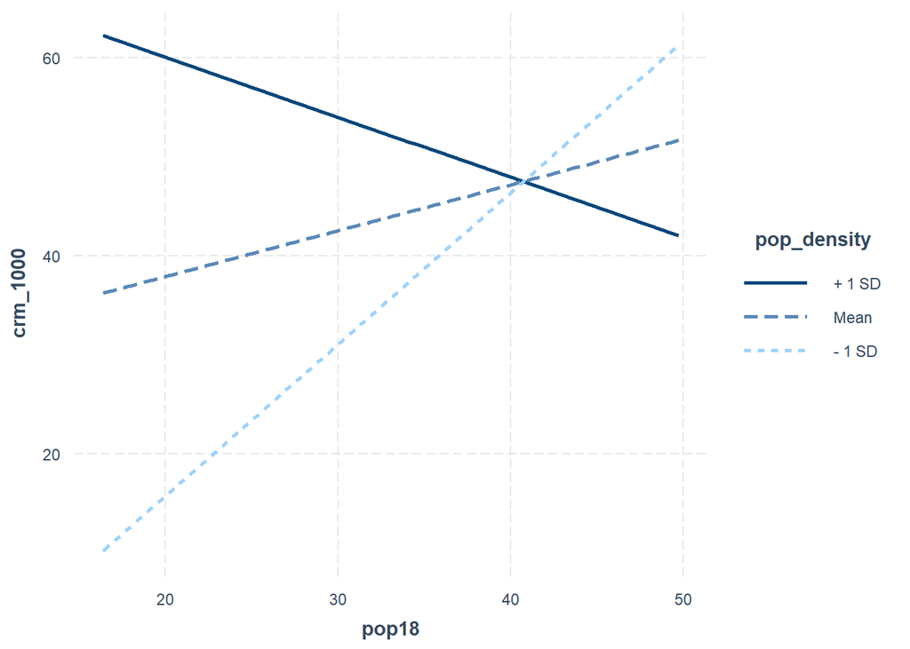

```r
interact_plot(fiti, pred = pop18, modx = pop_density)
```

### Backward Model

```r
fiti <- lm(crm_1000 ~ pop18 + bagrad + poverty + pcincome +
    totalinc + region + pop_density + beds_density_1000 + bagrad*pcincome + bagrad*pop_density, data = crime_df)
summary(fiti)
```

```
##
## Call:
## lm(formula = crm_1000 ~ pop18 + bagrad + poverty + pcincome +
##     totalinc + region + pop_density + beds_density_1000 + bagrad *
##     pcincome + bagrad * pop_density, data = crime_df)
##
## Residuals:
##     Min      1Q  Median      3Q     Max
## -59.147 -10.177  -0.915   9.618  60.267
##
## Coefficients:
##                      Estimate Std. Error t value Pr(>|t|)
## (Intercept)        -8.990e+01  1.647e+01  -5.457 8.23e-08 ***
## pop18               7.242e-01  2.751e-01   2.633 0.008778 **
## bagrad              1.867e+00  5.021e-01   3.718 0.000228 ***
## poverty             2.181e+00  2.906e-01   7.503 3.65e-13 ***
## pcincome            4.350e-03  7.999e-04   5.439 9.06e-08 ***
## totalinc            8.373e-05  7.336e-05   1.141 0.254364
## region2             1.216e+01  2.420e+00   5.024 7.46e-07 ***
## region3             2.912e+01  2.418e+00  12.044  < 2e-16 ***
## region4             2.447e+01  2.834e+00   8.634  < 2e-16 ***
## pop_density         9.032e-03  1.107e-03   8.161 3.76e-15 ***
## beds_density_1000   1.940e+00  4.973e-01   3.901 0.000111 ***
## bagrad:pcincome    -1.006e-04  2.348e-05  -4.283 2.28e-05 ***
## bagrad:pop_density -1.960e-04  4.872e-05  -4.023 6.80e-05 ***
## ---
## Signif. codes:  0 '***' 0.001 '**' 0.01 '*' 0.05 '.' 0.1 ' ' 1
##
## Residual standard error: 16.91 on 427 degrees of freedom
## Multiple R-squared:  0.6276, Adjusted R-squared:  0.6171
## F-statistic: 59.96 on 12 and 427 DF,  p-value: < 2.2e-16
```

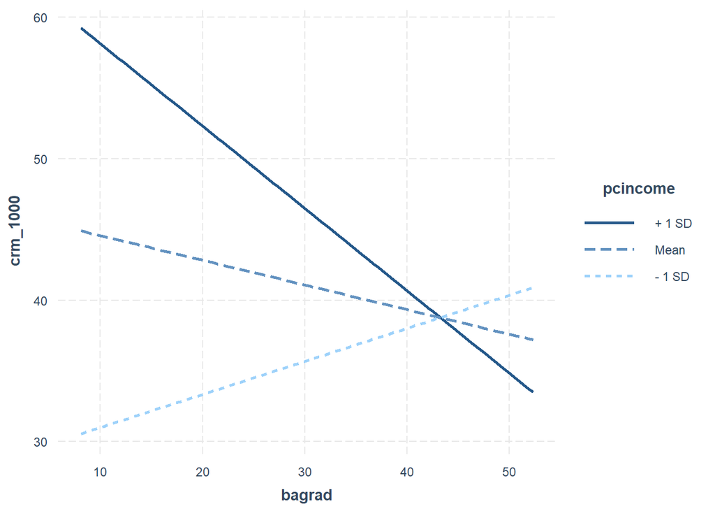

```r
interact_plot(fiti, pred = bagrad, modx = pcincome)
```

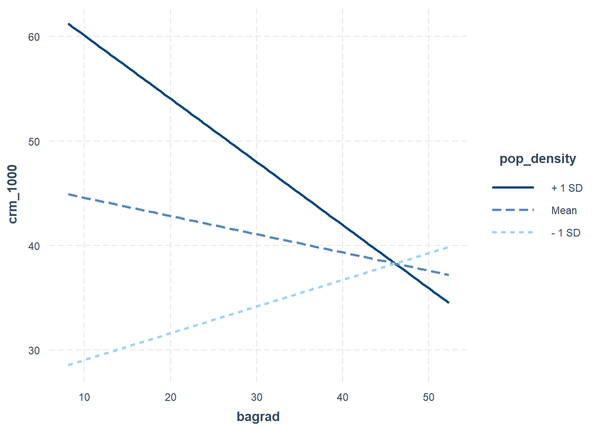

```r
interact_plot(fiti, pred = bagrad, modx = pop_density)
```

## Candidate models

```r
model_1 = lm(crm_1000 ~ pop18 +totalinc + poverty + beds_density_1000 + region + pop_density + pop18*pop_density, data = crime_df)

model_2 = lm(crm_1000 ~ pop18 + bagrad + poverty + pcincome + totalinc + region + pop_density + beds_density_1000, data = crime_df)

model_3 = lm(crm_1000 ~ pop18 + bagrad + poverty + pcincome + totalinc + region + pop_density + beds_density_1000 + bagrad*pcincome + bagrad*pop_density, data = crime_df)
```

## Model Diagnostics

### Boxcox Transformation

Model1

```r
bc <- boxcox(model_1, lambda = seq(-5, 5, by = 0.25))
```

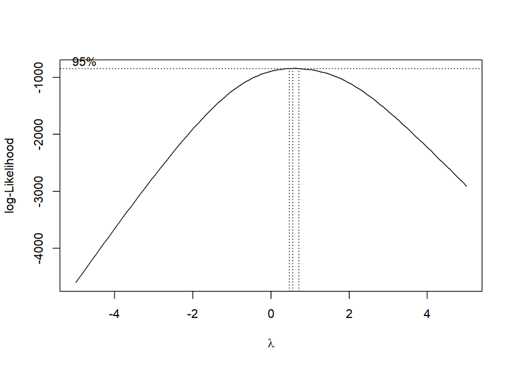

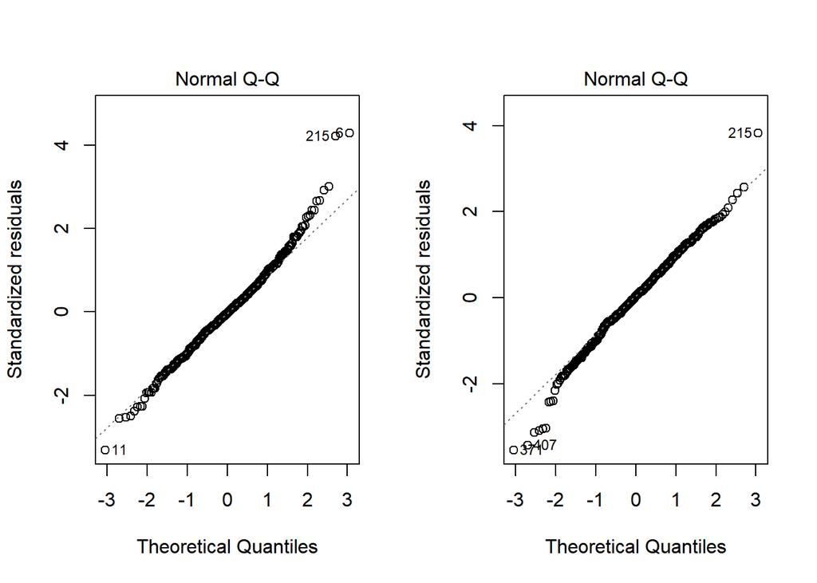

```r
lambda <- bc$x[which.max(bc$y)]
#choose power 1/2

crime_df$crm.bc <- crime_df$crm_1000^(1/2)
model_bc1 = lm(crm.bc ~ pop18 +totalinc + poverty + beds_density_1000 + region + pop_density + pop18*pop_density, data = crime_df)

par(mfrow = c(1,2))
plot(model_1, which = 2)
plot(model_bc1, which = 2)
```

```r
summary(model_1)
```

```
##
## Call:
## lm(formula = crm_1000 ~ pop18 + totalinc + poverty + beds_density_1000 +
##     region + pop_density + pop18 * pop_density, data = crime_df)
##
## Residuals:
##     Min      1Q  Median      3Q     Max
## -56.315 -11.345  -0.571  10.215  73.941
##
## Coefficients:
##                     Estimate Std. Error t value Pr(>|t|)
## (Intercept)       -1.201e+01  6.699e+00  -1.792  0.07383 .
## pop18              8.962e-01  2.213e-01   4.050 6.08e-05 ***
## totalinc           2.018e-04  7.064e-05   2.856  0.00449 **
## poverty            1.208e+00  2.119e-01   5.700 2.23e-08 ***
## beds_density_1000  2.982e+00  4.866e-01   6.129 2.01e-09 ***
## region2            1.001e+01  2.482e+00   4.032 6.55e-05 ***
## region3            2.725e+01  2.443e+00  11.155  < 2e-16 ***
## region4            2.350e+01  2.841e+00   8.273 1.65e-15 ***
## pop_density        1.984e-02  3.469e-03   5.721 1.99e-08 ***
## pop18:pop_density -4.872e-04  1.135e-04  -4.293 2.18e-05 ***
## ---
## Signif. codes:  0 '***' 0.001 '**' 0.01 '*' 0.05 '.' 0.1 ' ' 1
##
## Residual standard error: 17.63 on 430 degrees of freedom
## Multiple R-squared:  0.5921, Adjusted R-squared:  0.5836
## F-statistic: 69.36 on 9 and 430 DF,  p-value: < 2.2e-16
```

```r
summary(model_bc1)
```

```
##
## Call:
## lm(formula = crm.bc ~ pop18 + totalinc + poverty + beds_density_1000 +
##     region + pop_density + pop18 * pop_density, data = crime_df)
##
## Residuals:
##     Min      1Q  Median      3Q     Max
## -4.1476 -0.6532  0.0468  0.7784  4.4936
##
## Coefficients:
##                     Estimate Std. Error t value Pr(>|t|)
## (Intercept)        2.944e+00  4.482e-01   6.570 1.46e-10 ***
## pop18              5.472e-02  1.480e-02   3.696 0.000247 ***
## totalinc           1.683e-05  4.726e-06   3.562 0.000410 ***
## poverty            7.121e-02  1.418e-02   5.022 7.49e-07 ***
## beds_density_1000  2.076e-01  3.255e-02   6.377 4.67e-10 ***
## region2            7.061e-01  1.660e-01   4.253 2.59e-05 ***
## region3            1.898e+00  1.634e-01  11.614  < 2e-16 ***
## region4            1.727e+00  1.900e-01   9.085  < 2e-16 ***
## pop_density        8.191e-04  2.320e-04   3.530 0.000460 ***
## pop18:pop_density -1.923e-05  7.592e-06  -2.534 0.011645 *
## ---
## Signif. codes:  0 '***' 0.001 '**' 0.01 '*' 0.05 '.' 0.1 ' ' 1
##
## Residual standard error: 1.18 on 430 degrees of freedom
## Multiple R-squared:  0.5486, Adjusted R-squared:  0.5391
## F-statistic: 58.06 on 9 and 430 DF,  p-value: < 2.2e-16
```

Model2

```r
bc <- boxcox(model_2, lambda = seq(-5, 5, by = 0.25))
```

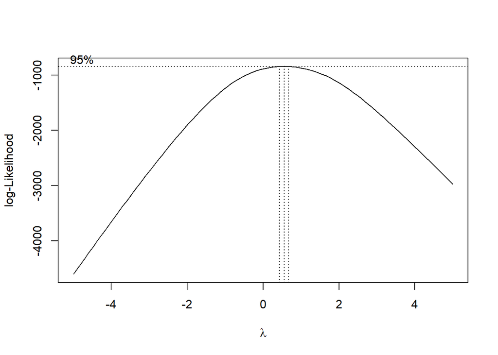

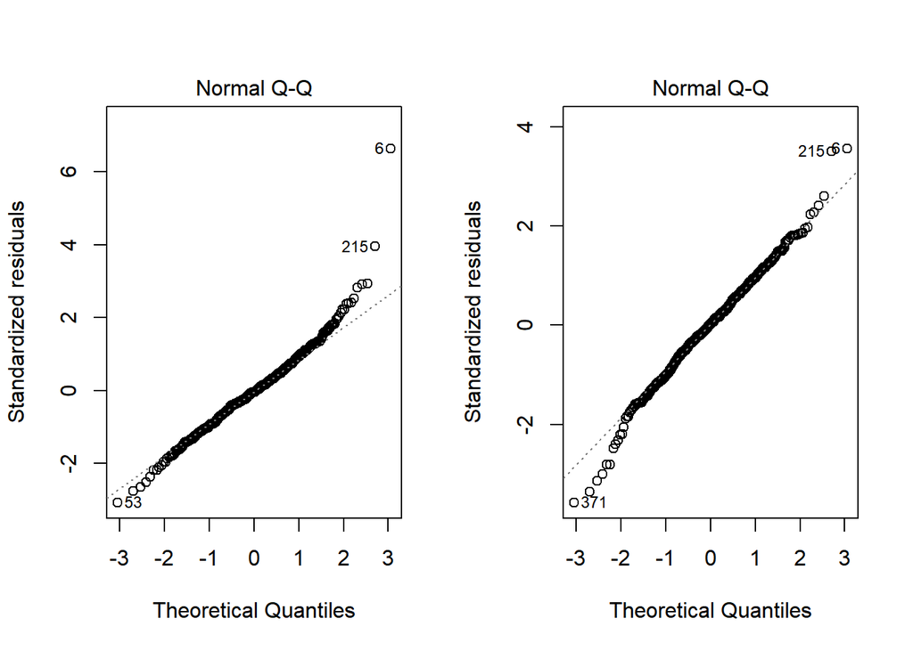

```r
lambda <- bc$x[which.max(bc$y)]
#choose power 1/2

crime_df$crm.bc <- crime_df$crm_1000^(1/2)
model_bc2 = lm(crm.bc ~ pop18 + bagrad + poverty + pcincome + totalinc + region + pop_density + beds_density_1000, data = crime_df)

par(mfrow = c(1,2))
plot(model_2, which = 2)
plot(model_bc2, which = 2)
```

```r
summary(model_2)
```

```
##
## Call:
## lm(formula = crm_1000 ~ pop18 + bagrad + poverty + pcincome +
##     totalinc + region + pop_density + beds_density_1000, data = crime_df)
##
## Residuals:
##     Min      1Q  Median      3Q     Max
## -51.532 -11.110  -0.727   9.967  79.427
##
## Coefficients:
##                     Estimate Std. Error t value Pr(>|t|)
## (Intercept)       -1.959e+01  1.214e+01  -1.614  0.10728
## pop18              7.508e-01  2.864e-01   2.622  0.00906 **
## bagrad            -2.184e-01  2.226e-01  -0.981  0.32709
## poverty            1.569e+00  2.849e-01   5.507 6.30e-08 ***
## pcincome           8.141e-04  4.547e-04   1.790  0.07413 .
## totalinc           1.886e-04  7.639e-05   2.469  0.01394 *
## region2            1.085e+01  2.563e+00   4.234 2.81e-05 ***
## region3            2.704e+01  2.544e+00  10.629  < 2e-16 ***
## region4            2.308e+01  2.980e+00   7.743 7.05e-14 ***
## pop_density        4.843e-03  4.491e-04  10.784  < 2e-16 ***
## beds_density_1000  2.577e+00  5.046e-01   5.108 4.92e-07 ***
## ---
## Signif. codes:  0 '***' 0.001 '**' 0.01 '*' 0.05 '.' 0.1 ' ' 1
##
## Residual standard error: 17.96 on 429 degrees of freedom
## Multiple R-squared:  0.578,  Adjusted R-squared:  0.5682
## F-statistic: 58.76 on 10 and 429 DF,  p-value: < 2.2e-16
```

```r
summary(model_bc2)
```

```
##
## Call:
## lm(formula = crm.bc ~ pop18 + bagrad + poverty + pcincome + totalinc +
##     region + pop_density + beds_density_1000, data = crime_df)
##
## Residuals:
##     Min      1Q  Median      3Q     Max
## -4.1813 -0.6894  0.0230  0.7638  4.0506
##
## Coefficients:
##                     Estimate Std. Error t value Pr(>|t|)
## (Intercept)        1.465e+00  7.963e-01   1.840  0.06653 .
## pop18              6.222e-02  1.879e-02   3.311  0.00101 **
## bagrad            -2.174e-02  1.460e-02  -1.489  0.13735
## poverty            1.043e-01  1.869e-02   5.579 4.30e-08 ***
## pcincome           8.347e-05  2.984e-05   2.797  0.00539 **
## totalinc           1.317e-05  5.013e-06   2.627  0.00893 **
## region2            7.888e-01  1.682e-01   4.690 3.68e-06 ***
## region3            1.935e+00  1.669e-01  11.589  < 2e-16 ***
## region4            1.766e+00  1.956e-01   9.029  < 2e-16 ***
## pop_density        2.128e-04  2.947e-05   7.222 2.35e-12 ***
## beds_density_1000  1.811e-01  3.311e-02   5.470 7.68e-08 ***
## ---
## Signif. codes:  0 '***' 0.001 '**' 0.01 '*' 0.05 '.' 0.1 ' ' 1
##
## Residual standard error: 1.178 on 429 degrees of freedom
## Multiple R-squared:  0.5506, Adjusted R-squared:  0.5402
## F-statistic: 52.57 on 10 and 429 DF,  p-value: < 2.2e-16
```

Model3

```r
bc <- boxcox(model_3, lambda = seq(-5, 5, by = 0.25))
```

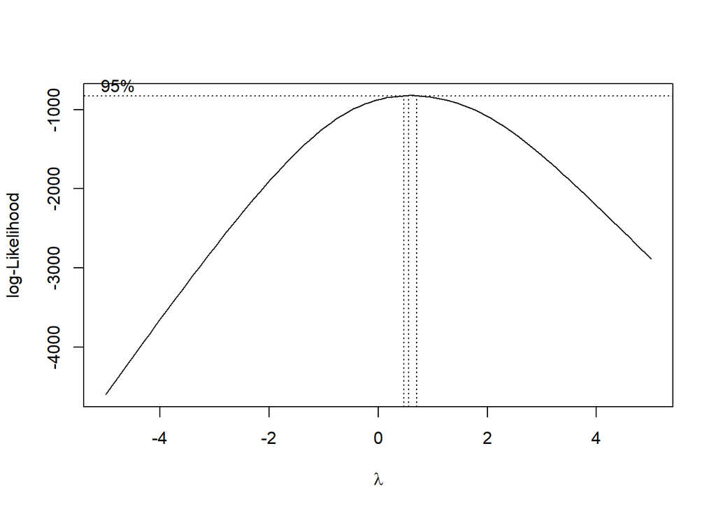

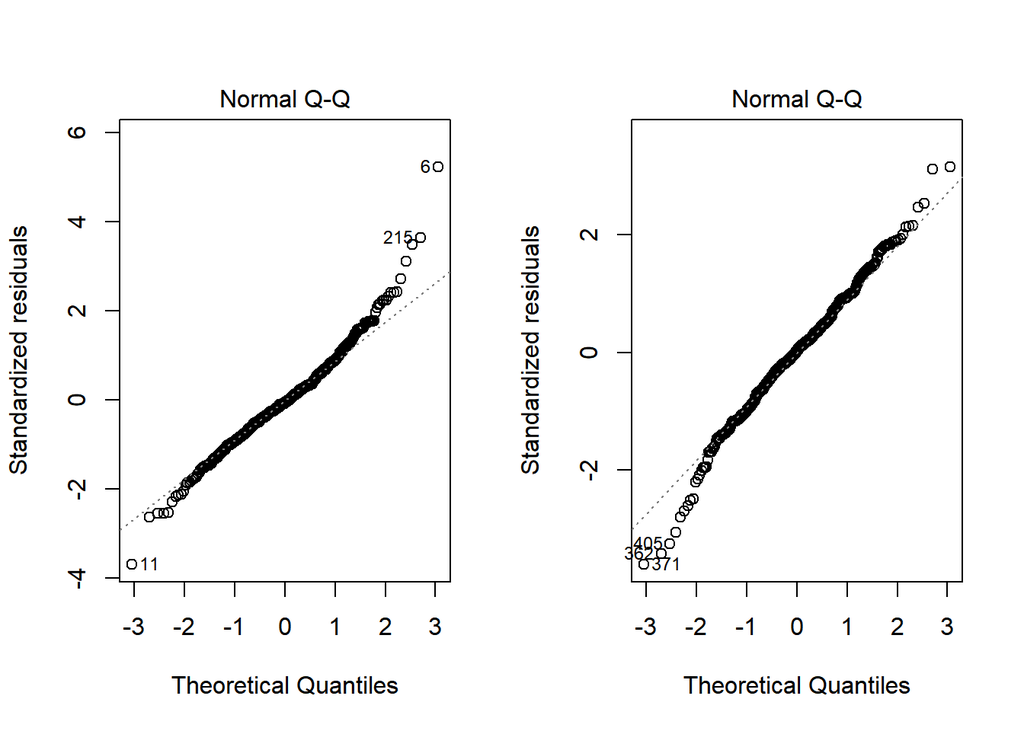

```r
lambda <- bc$x[which.max(bc$y)]
#choose power 1/2

crime_df$crm.bc <- crime_df$crm_1000^(1/2)
model_bc3 = lm(crm.bc ~ pop18 + bagrad + poverty + pcincome + totalinc + region + pop_density + beds_density_1000 + bagrad*pcincome + bagrad*pop_density, data = crime_df)

par(mfrow = c(1,2))
plot(model_3, which = 2)
plot(model_bc3, which = 2)
```

```r
summary(model_3)
```

```
##
## Call:
## lm(formula = crm_1000 ~ pop18 + bagrad + poverty + pcincome +
##     totalinc + region + pop_density + beds_density_1000 + bagrad *
##     pcincome + bagrad * pop_density, data = crime_df)
##
## Residuals:
##     Min      1Q  Median      3Q     Max
## -59.147 -10.177  -0.915   9.618  60.267
##
## Coefficients:
##                      Estimate Std. Error t value Pr(>|t|)
## (Intercept)        -8.990e+01  1.647e+01  -5.457 8.23e-08 ***
## pop18               7.242e-01  2.751e-01   2.633 0.008778 **
## bagrad              1.867e+00  5.021e-01   3.718 0.000228 ***
## poverty             2.181e+00  2.906e-01   7.503 3.65e-13 ***
## pcincome            4.350e-03  7.999e-04   5.439 9.06e-08 ***
## totalinc            8.373e-05  7.336e-05   1.141 0.254364
## region2             1.216e+01  2.420e+00   5.024 7.46e-07 ***
## region3             2.912e+01  2.418e+00  12.044  < 2e-16 ***
## region4             2.447e+01  2.834e+00   8.634  < 2e-16 ***
## pop_density         9.032e-03  1.107e-03   8.161 3.76e-15 ***
## beds_density_1000   1.940e+00  4.973e-01   3.901 0.000111 ***
## bagrad:pcincome    -1.006e-04  2.348e-05  -4.283 2.28e-05 ***
## bagrad:pop_density -1.960e-04  4.872e-05  -4.023 6.80e-05 ***
## ---
## Signif. codes:  0 '***' 0.001 '**' 0.01 '*' 0.05 '.' 0.1 ' ' 1
##
## Residual standard error: 16.91 on 427 degrees of freedom
## Multiple R-squared:  0.6276, Adjusted R-squared:  0.6171
## F-statistic: 59.96 on 12 and 427 DF,  p-value: < 2.2e-16
```

```r
summary(model_bc3)
```

```
##
## Call:
## lm(formula = crm.bc ~ pop18 + bagrad + poverty + pcincome + totalinc +
##     region + pop_density + beds_density_1000 + bagrad * pcincome +
##     bagrad * pop_density, data = crime_df)
##
## Residuals:
##     Min      1Q  Median      3Q     Max
## -4.0257 -0.6925  0.0322  0.6745  3.5136
##
## Coefficients:
##                      Estimate Std. Error t value Pr(>|t|)
## (Intercept)        -3.173e+00  1.098e+00  -2.889 0.004062 **
## pop18               5.539e-02  1.834e-02   3.021 0.002672 **
## bagrad              1.301e-01  3.347e-02   3.887 0.000118 ***
## poverty             1.459e-01  1.937e-02   7.533 2.99e-13 ***
## pcincome            3.282e-04  5.332e-05   6.156 1.72e-09 ***
## totalinc            6.965e-06  4.890e-06   1.424 0.155068
## region2             8.582e-01  1.613e-01   5.320 1.68e-07 ***
## region3             2.033e+00  1.612e-01  12.612  < 2e-16 ***
## region4             1.809e+00  1.889e-01   9.573  < 2e-16 ***
## pop_density         3.613e-04  7.377e-05   4.898 1.38e-06 ***
## beds_density_1000   1.338e-01  3.315e-02   4.036 6.45e-05 ***
## bagrad:pcincome    -7.504e-06  1.565e-06  -4.794 2.26e-06 ***
## bagrad:pop_density -6.847e-06  3.248e-06  -2.108 0.035588 *
## ---
## Signif. codes:  0 '***' 0.001 '**' 0.01 '*' 0.05 '.' 0.1 ' ' 1
##
## Residual standard error: 1.127 on 427 degrees of freedom
## Multiple R-squared:  0.5907, Adjusted R-squared:  0.5792
## F-statistic: 51.36 on 12 and 427 DF,  p-value: < 2.2e-16
```

### Residuals

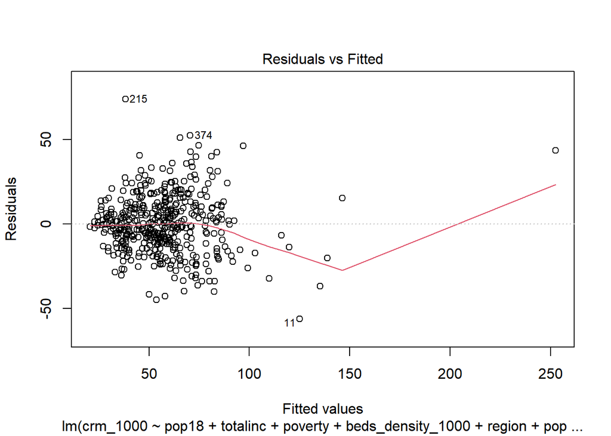

```r
plot(model_1, which = 1)
```

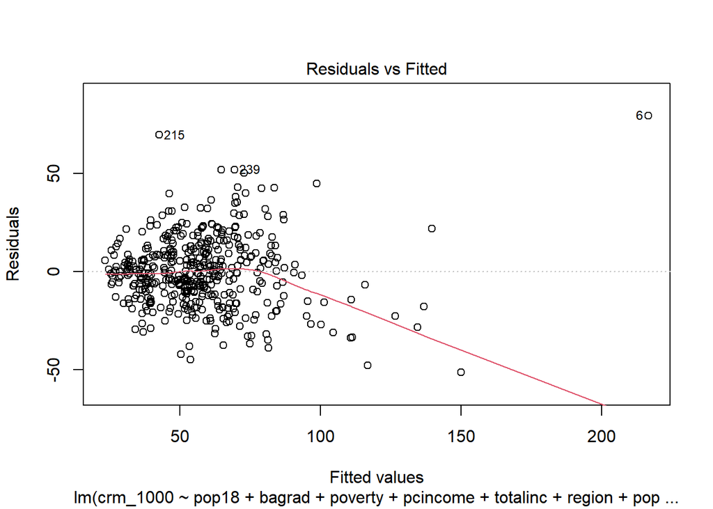

```r
plot(model_2, which = 1)
```

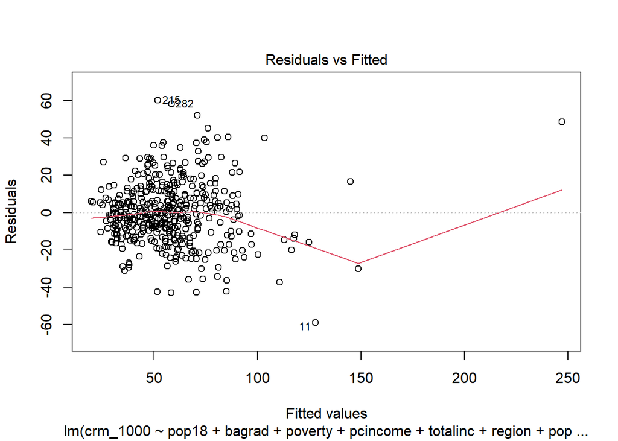

```r
plot(model_3, which = 1)
```

observation #6, #215

### Normal QQ plots

Filter out influential observations

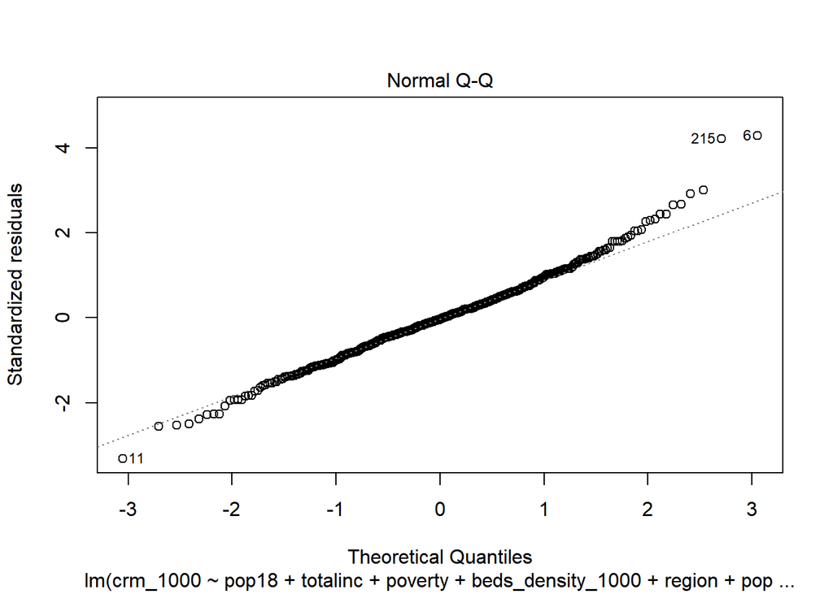

```r
plot(model_1, which = 2)
```

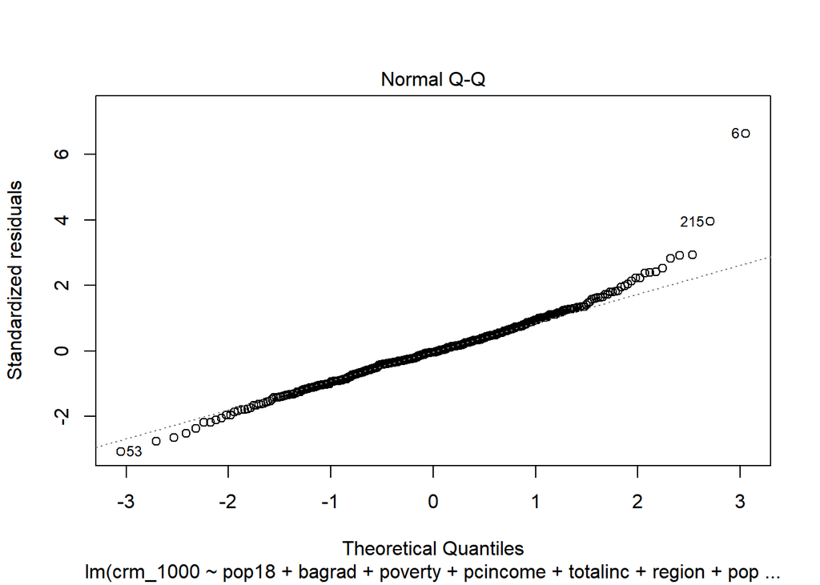

```r
plot(model_2, which = 2)
```

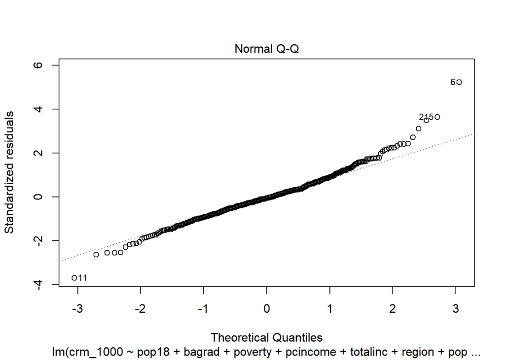

```r
plot(model_3, which = 2)
```

### Scale and locations

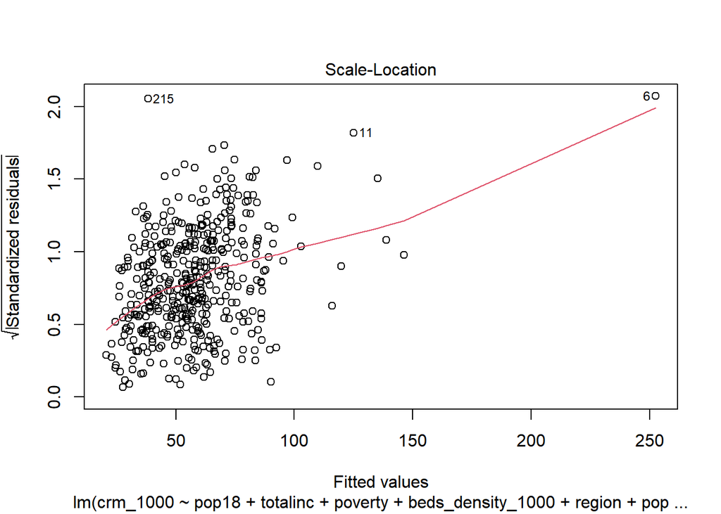

```r
plot(model_1, which = 3)
```

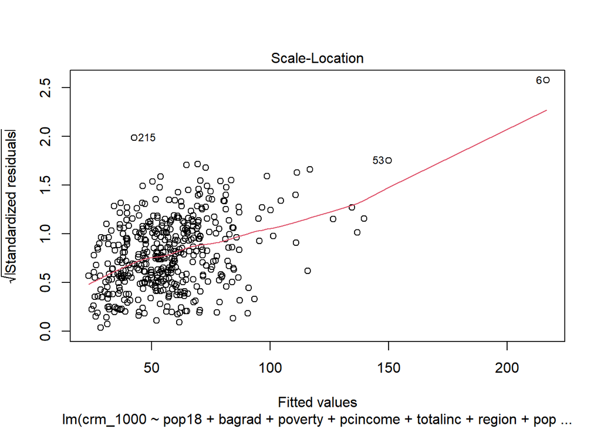

```r
plot(model_2, which = 3)
```

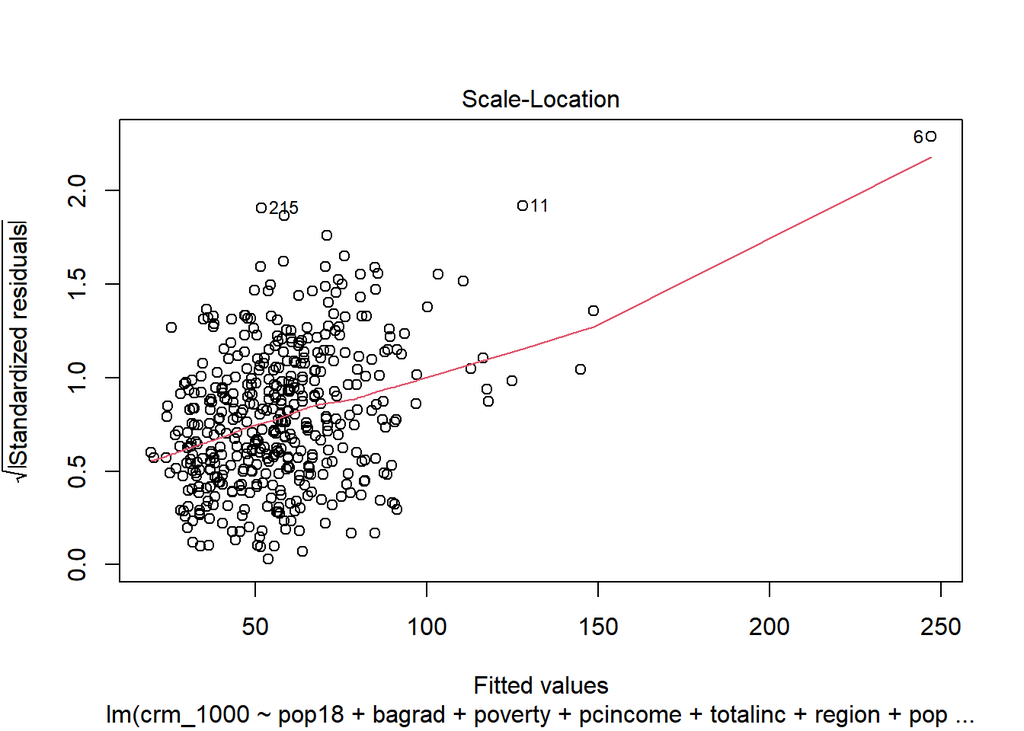

```r
plot(model_3, which = 3)
```

### Outliers and Leverage

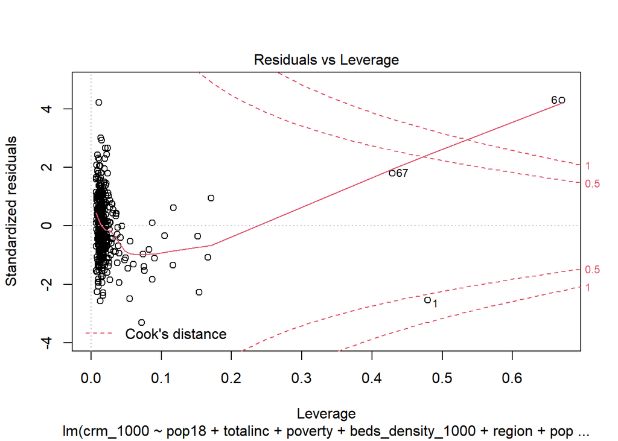

```r
plot(model_1, which = 5)
```

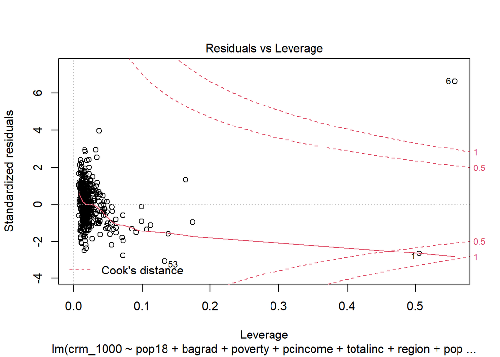

```r
plot(model_2, which = 5)
```

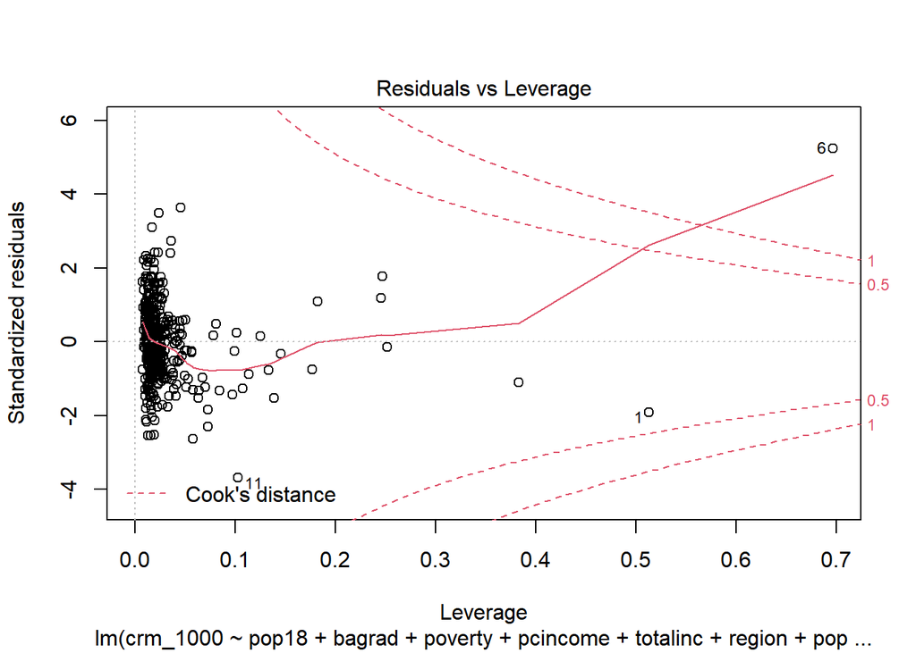

```r
plot(model_3, which = 5)
```

observation #1, #6

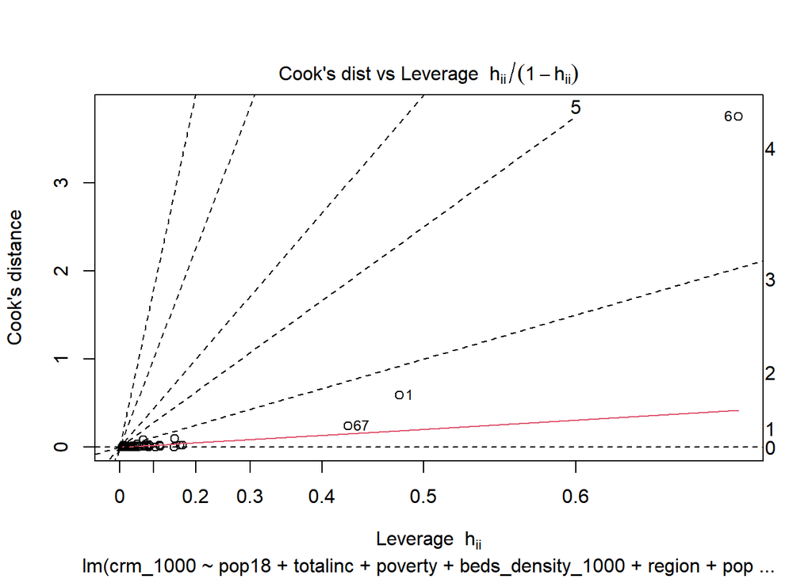

```r
plot(model_1, which = 6)
```